# Course project 1

## Getting the data

### the data in the activity file is read using read.csv() function and stored in activity variable

```r
activity<-read.csv("activity.csv")
```

## Processsing data

### The cleanData dataset is created from the original dataset.

this data set has no NA values

```r
activity$day<-weekdays(as.Date(activity$date))
cleanData<-activity[!is.na(activity$steps),]
```

the dataset with the NA values is also subsetted and stored in naData variable

```r
naData<-activity[is.na(activity$steps),]
```

## Total Number of steps per day

A new variable sumSteps is created by adding up the steps taken in each day.

```r
 sumSteps<-aggregate(cleanData$steps~cleanData$date,FUN=sum)
 colnames(sumSteps)<-c("date","steps")
```

This is created from the cleaData dataset because the frist probelm need not involve the NA  
variables  
### Histogram for total number of steps perday

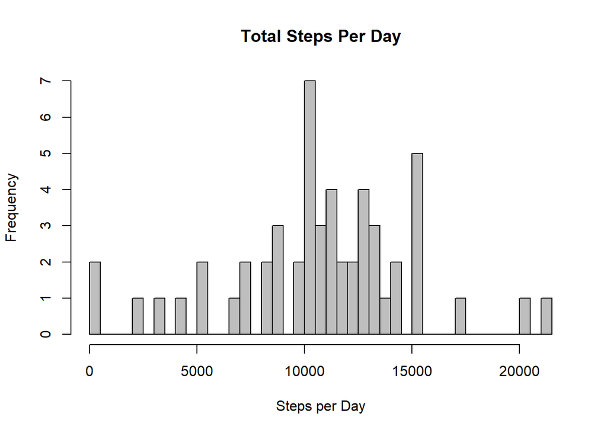

```r
hist(sumSteps$steps,breaks = 53,col = "grey",xlab = "Steps per Day",main = "Total Steps Per Day")
```

### Mean and median

The mean and the median of the total number of steps taken perday is calculated

```r
as.numeric(mean(sumSteps$steps))
```

```
## [1] 10766.19
```

```r
as.numeric(median(sumSteps$steps))
```

```
## [1] 10765
```

### Time series plot

```r
intervalAgg<-aggregate(cleanData$steps~cleanData$interval,FUN = mean)
colnames(intervalAgg)<-c("interval","steps")
```

now the times series plot!!

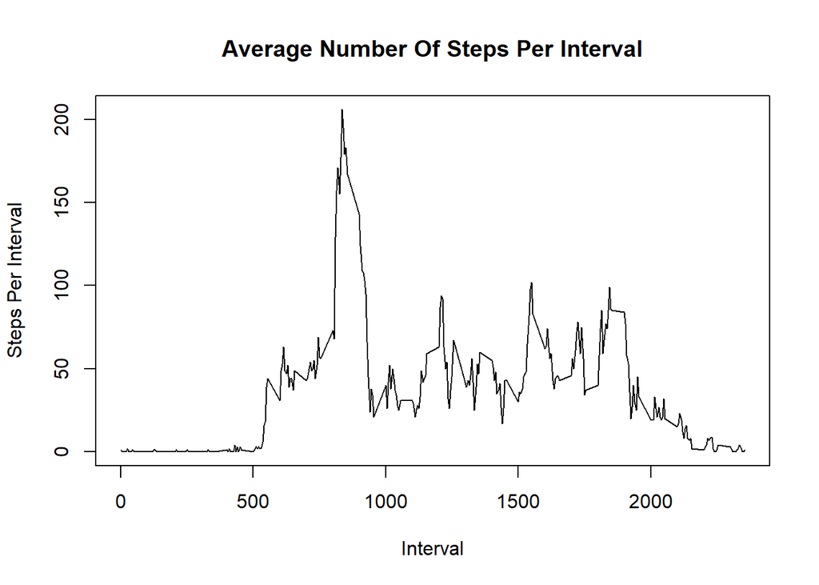

```r
plot(intervalAgg$interval,intervalAgg$steps,type = "l",xlab = "Interval",ylab = "Steps Per Interval",main = "Average Number Of Steps Per Interval")
```

## The Interval that contains the maximim no of steps

```r
maxSteps<-max(intervalAgg$steps)
intervalAgg[intervalAgg$steps==maxSteps,1]
```

```
## [1] 835
```

## The maximum number of steps per Interval

```r
print(maxSteps)
```

```
## [1] 206
```

## Imputing the missing values

```r
nrow(naData)
```

```
## [1] 2304
```

the total number of the missing rows is 2304

### Creating a new average table including day

```r
newavg<-aggregate(cleanData$steps~cleanData$interval+cleanData$day,FUN = mean)
colnames(newavg)<-c("interval","day","steps")
newavg<-newavg[order(newavg$interval),]
```

### merge the nadata with the newaverage data

```r
newdata<-merge(naData,newavg,by=c("interval","day"))
colnames(newdata)<-c("interval", "day", "steps", "date","Avg")
```

### Create a table identical to the original but the missing data filled

```r
newdata2<-newdata[,c(5,4,2,1)]
colnames(newdata2)<-c("steps","date","interval","day")

mergedata<-rbind(cleanData,newdata2)
```

### Create a new histogram

```r
 sumSteps2<-aggregate(mergedata$steps~mergedata$date,FUN=sum)
 colnames(sumSteps2)<-c("date","steps")

 as.numeric(mean(sumSteps2$steps))
```

```
## [1] 10821.21
```

```r
 as.numeric(mean(sumSteps$steps))
```

```
## [1] 10766.19
```

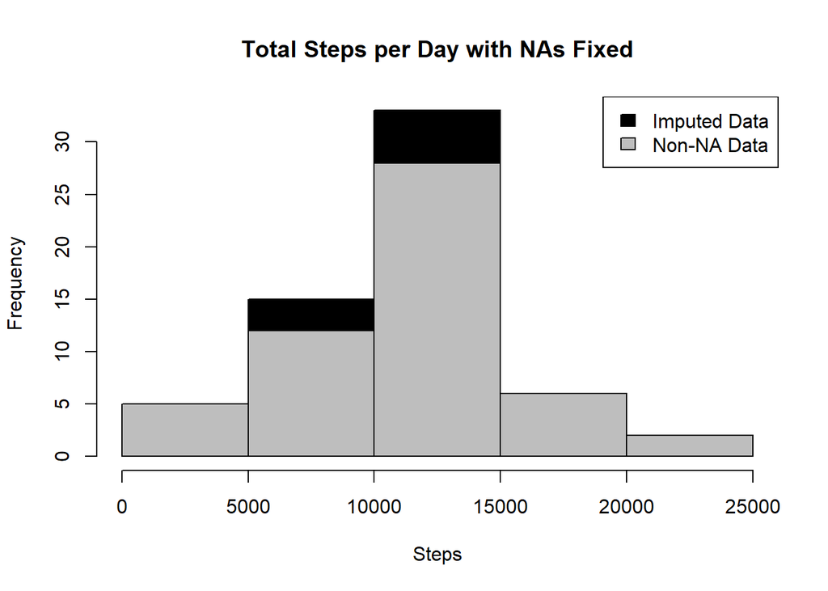

```r
 hist(sumSteps2$steps, breaks=5, xlab="Steps", main = "Total Steps per Day with NAs Fixed", col="Black")
hist(sumSteps$steps, breaks=5, xlab="Steps", main = "Total Steps per Day with NAs Fixed", col="Grey", add=T)
legend("topright", c("Imputed Data", "Non-NA Data"), fill=c("black", "grey") )
```

## Find if there is a change in the pattern

Create a new factor variable in the dataset with two levels - “weekday” and “weekend” indicating whether a given date is a weekday or weekend day.

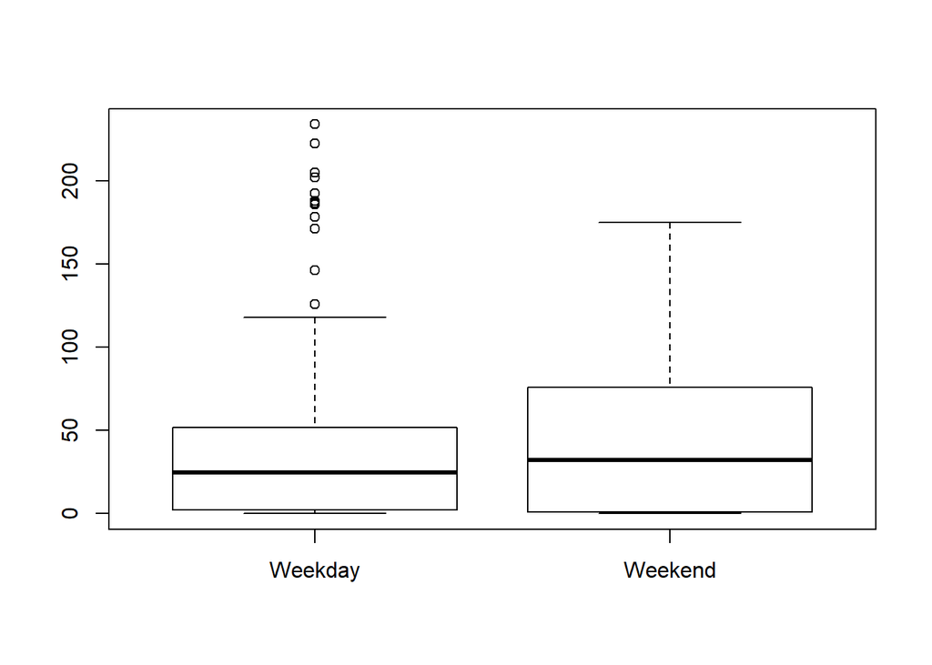

```r
mergedata$DayCategory <- ifelse(mergedata$day %in% c("Saturday", "Sunday"), "Weekend", "Weekday")
intervalTable<-aggregate(mergedata$steps~mergedata$interval+mergedata$DayCategory,FUN=mean)
colnames(intervalTable)<-c("interval","Datcat","steps")
plot(factor(intervalTable$Datcat),intervalTable$steps)
```